# Reproducible Research

Hamza Hanif

July 3, 2018

### Introduction

It is now possible to collect a large amount of data about personal movement using activity monitoring devices such as a Fitbit, Nike Fuelband, or Jawbone Up. These type of devices are part of the “quantified self” movement - a group of enthusiasts who take measurements about themselves regularly to improve their health, to find patterns in their behavior, or because they are tech geeks. But these data remain under-utilized both because the raw data are hard to obtain and there is a lack of statistical methods and software for processing and interpreting the data.

This assignment makes use of data from a personal activity monitoring device. This device collects data at 5 minute intervals through out the day. The data consists of two months of data from an anonymous individual collected during the months of October and November, 2012 and include the number of steps taken in 5 minute intervals each day.

The data for this assignment can be downloaded from the course web site:

- [Activity monitoring data](https://d396qusza40orc.cloudfront.net/repdata%2Fdata%2Factivity.zip)

The dataset is stored in a comma-separated-value (CSV) file and there are a total of 17,568 observations in this dataset.

#### Reading data

```r
activity_data <- read.csv("activity.csv", header = TRUE, sep = ",", na.strings = "NA")
activity_data$date <- as.Date(activity_data$date, format = "%Y-%m-%d")
activity_data$interval <- factor(activity_data$interval)


summary(activity_data)
```

```
##      steps             date               interval
##  Min.   :  0.00   Min.   :2012-10-01   0      :   61
##  1st Qu.:  0.00   1st Qu.:2012-10-16   5      :   61
##  Median :  0.00   Median :2012-10-31   10     :   61
##  Mean   : 37.38   Mean   :2012-10-31   15     :   61
##  3rd Qu.: 12.00   3rd Qu.:2012-11-15   20     :   61
##  Max.   :806.00   Max.   :2012-11-30   25     :   61
##  NA's   :2304                          (Other):17202
```

```r
str(activity_data)
```

```
## 'data.frame':    17568 obs. of  3 variables:
##  $ steps   : int  NA NA NA NA NA NA NA NA NA NA ...
##  $ date    : Date, format: "2012-10-01" "2012-10-01" ...
##  $ interval: Factor w/ 288 levels "0","5","10","15",..: 1 2 3 4 5 6 7 8 9 10 ...
```

```r
dim(activity_data)
```

```
## [1] 17568     3
```

```r
head(activity_data)
```

```
##   steps       date interval
## 1    NA 2012-10-01        0
## 2    NA 2012-10-01        5
## 3    NA 2012-10-01       10
## 4    NA 2012-10-01       15
## 5    NA 2012-10-01       20
## 6    NA 2012-10-01       25
```

The output shows that same amount of observations and variable as mentioned in introdution.

#### Total number of steps taken each day

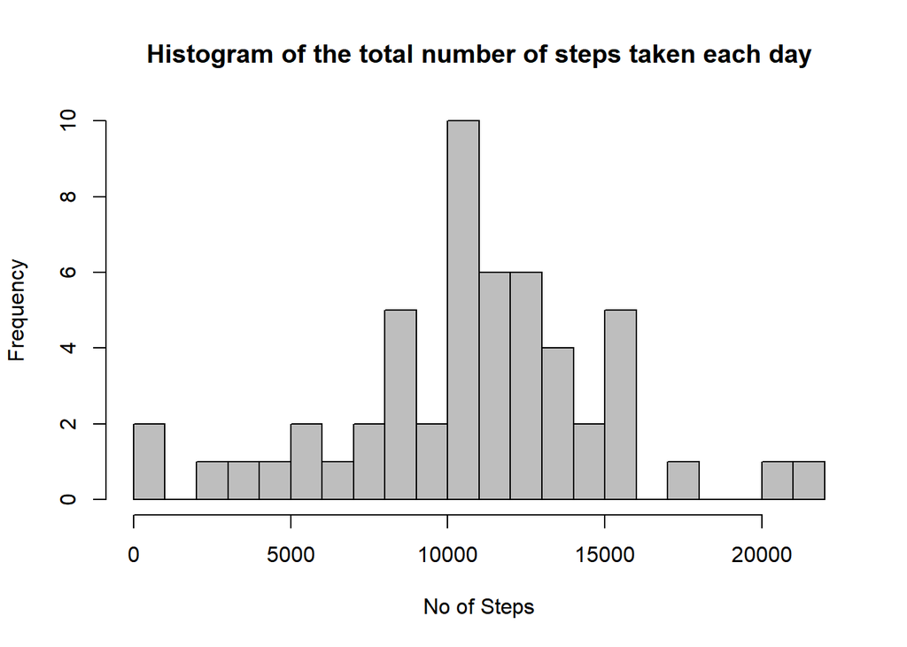

```r
#ignore missing values
NA_index <- is.na(as.character(activity_data$steps))
data_no_NA <- activity_data[!NA_index,]
steps_day <- aggregate(steps ~ date, data = data_no_NA, sum)

#plot
hist(as.numeric(steps_day$steps), col='grey',breaks = 20, xlab = "No of Steps", main= "Histogram of the total number of steps taken each day")
```

#### Mean and median number of steps taken each day

```r
mean(steps_day$steps)
```

```
## [1] 10766.19
```

```r
median(steps_day$steps)
```

```
## [1] 10765
```

#### Time series plot of the average number of steps taken

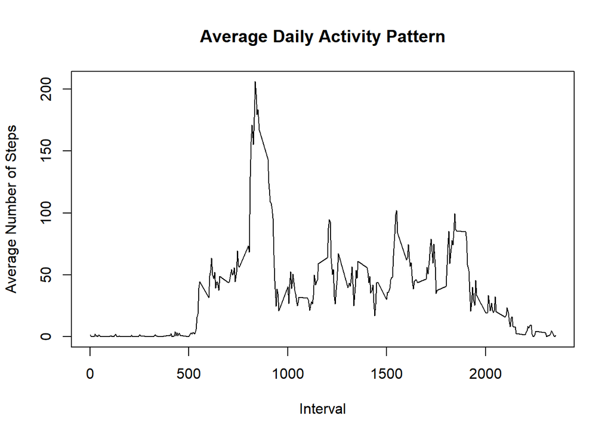

```r
steps_int <- aggregate(data_no_NA$steps, by=list(interval=data_no_NA$interval), FUN=mean)

steps_per_interval <- aggregate(data_no_NA$steps, by=list(interval=data_no_NA$interval), FUN=mean)

colnames(steps_int) <- c("interval", "average_steps")

#plot
plot(as.integer(levels(steps_int$interval)), steps_int$average_steps, type="l",
     xlab = "Interval", ylab = "Average Number of Steps", main = "Average Daily Activity Pattern")
```

#### 5-minute interval that contains the maximum number of steps

```r
max(steps_int$average_steps)
```

```
## [1] 206.1698
```

```r
steps_int[which.max(steps_int$average_steps),]$interval
```

```
## [1] 835
## 288 Levels: 0 5 10 15 20 25 30 35 40 45 50 55 100 105 110 115 120 ... 2355
```

The 5-minute interval which contains maximum number of steps, 206.2 is at interval 835.

#### Imputing missing values

```r
sum(is.na(as.character(activity_data$steps))) # for steps
```

```
## [1] 2304
```

```r
sum(is.na(as.character(activity_data$date)))  # for date
```

```
## [1] 0
```

```r
sum(is.na(as.character(activity_data$interval))) #for interval
```

```
## [1] 0
```

The total no of missing values is 2304.

#### Creating a new data set with missing values replaced by mean of 5-mint interval.

```r
NA_index <- which(is.na(as.character(activity_data$steps)))
comp_data <- activity_data
comp_data[NA_index, ]$steps<-unlist(lapply(NA_index, FUN=function(NA_index){
                steps_int[activity_data[NA_index,]$interval==steps_per_interval$interval,]$average_steps
                }))
```

A histogram of a new data set

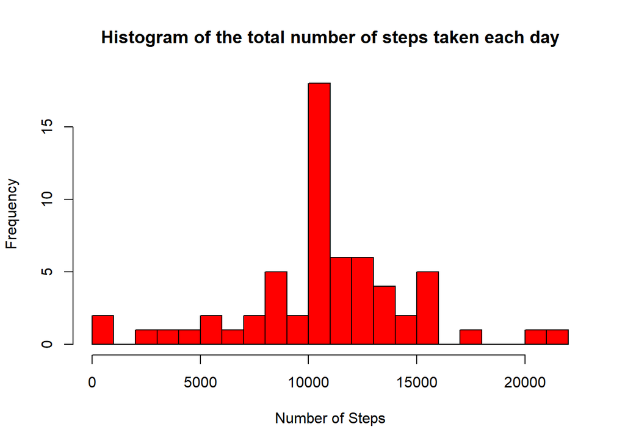

```r
steps_day_comp <- aggregate(steps ~ date, data = comp_data, sum)
#plot
hist(as.numeric(steps_day_comp$steps), breaks = 20, col = "red", xlab = "Number of Steps", main= "Histogram of the total number of steps taken each day")
```

#### Mean and median number of complete data set

```r
mean(steps_day_comp$steps)
```

```
## [1] 10766.19
```

```r
median(steps_day_comp$steps)
```

```
## [1] 10766.19
```

#### Comparing the average number of steps taken per 5-minute interval across weekdays and weekends via plot

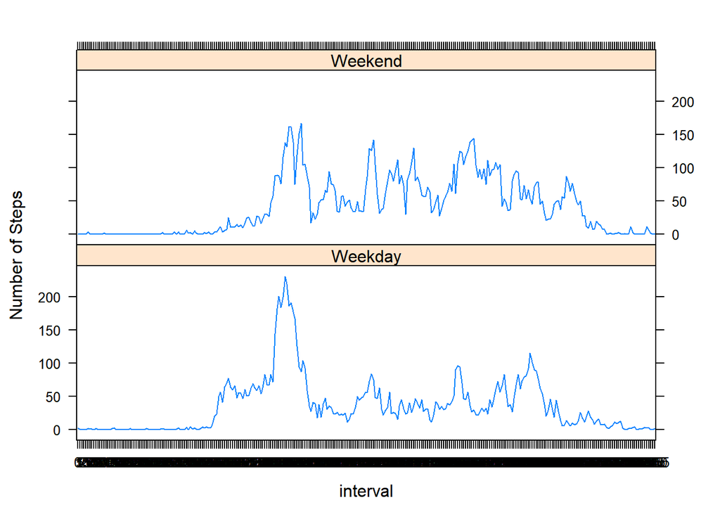

```r
comp_data$day <- as.factor(weekdays(comp_data$date))
comp_data$is_weekday <- ifelse(!(comp_data$day %in% c("Saturday","Sunday")), TRUE, FALSE)

weekdays_data <- comp_data[comp_data$is_weekday,]
steps_per_interval_weekdays <- aggregate(weekdays_data$steps, by=list(interval=weekdays_data$interval), FUN=mean)

weekends_data <- comp_data[!comp_data$is_weekday,]
steps_per_interval_weekends <- aggregate(weekends_data$steps, by=list(interval=weekends_data$interval), FUN=mean)

colnames(steps_per_interval_weekdays) <- c("interval", "average_steps")
colnames(steps_per_interval_weekends) <- c("interval", "average_steps")
steps_per_interval_weekdays$day <- "Weekday"
steps_per_interval_weekends$day <- "Weekend"

week_data <- rbind(steps_per_interval_weekends, steps_per_interval_weekdays)
week_data$day <- as.factor(week_data$day)

#Making the plot
library(lattice)
xyplot(average_steps ~  interval | day, data = week_data, layout = c(1,2), type ="l", ylab="Number of Steps")
```

Yes, there is a difference of average number of steps taken per 5-minute interval across weekdays and weekends.